# New York City Taxi Network Analysis

2024-12-03

# Introduction

Understanding the dynamics of urban transportation systems is vital for optimizing mobility and resource allocation in large metropolitan areas. New York City, with its extensive taxi network, provides a rich context for exploring the spatial and temporal patterns of urban mobility. This study examines the city’s taxi network using data from the New York City Taxi and Limousine Commission (TLC), offering insights into zone interactions, trip flows, and accessibility.

The analysis addresses several research questions central to understanding NYC’s taxi network: Which zones serve as the most important hubs in the network? How do inter-borough trip flows compare to intra-borough flows? Which zones exhibit the highest and lowest accessibility, and what factors influence these differences? What role do airports play within the network compared to other zones?

By employing network analysis and spatial modelling, the study explores the interactions between key urban zones, identifies critical hubs, and evaluates the structural and functional characteristics of the taxi network. These findings contribute to a broader understanding of urban transportation systems and offer potential pathways for improving connectivity and accessibility within the city.

# Literature review

The study of New York City’s taxi network has offered significant insights into urban transportation systems and mobility patterns. Researchers have utilised large datasets and advanced analytical methods to explore spatial connectivity, temporal demand, and the interplay of various transportation modes.

Schneider (2015) analysed over 1.1 billion taxi and Uber trips in NYC between 2009 and 2015. This work uncovered patterns in pickups, drop-offs, and fare structures, revealing the role of key urban zones such as business districts and residential areas in shaping taxi demand. Schneider’s study highlighted the evolving relationship between traditional taxis and rideshare services, offering a detailed comparison of their contributions to NYC’s transportation network. This analysis emphasized the value of integrating data-driven approaches to optimize traffic flows and resource allocation.

Deri and Moura (2015) applied graph theory to NYC’s taxi network, modelling it as a transportation graph and performing spectral analysis using the graph Fourier transform. Their findings demonstrated the importance of critical hubs, clustering tendencies, and connectivity within the network. By identifying areas of high mobility and isolated zones, this study provided a nuanced understanding of network efficiency and the structural dynamics of urban transportation systems.

Gilbride et al. (2017) examined NYC’s taxi demand using ESRI’s Network Analyst, focusing on seasonal variations and spatial patterns. Their research highlighted the concentration of demand in commercial and tourist hotspots, particularly within Manhattan’s grid network. The use of visualisation tools offered actionable insights for addressing congestion and improving mobility by identifying high-demand locations and temporal fluctuations.

Together, these studies illustrate the utility of network analysis and spatial data in understanding urban transportation systems. They demonstrate how applying graph theory, data visualisation, and comprehensive datasets can inform decision-making, from optimizing taxi operations to planning urban mobility interventions.

# Data preprocessing

The analysis utilises several datasets provided by the New York City Taxi and Limousine Commission (TLC). The data includes July 2024 trip records for Yellow Taxi, Green Taxi, For-Hire Vehicle, and High-Volume For-Hire Vehicle services, all in PARQUET format. It also incorporates the Taxi Zone Lookup Table in CSV format and the Taxi Zone Shapefile for spatial analysis.

```r
yellow <- read_parquet('data/yellow_tripdata_2024-07.parquet') %>%
  glimpse()
```

```
## Rows: 3,076,903
## Columns: 19
## $ VendorID              <int> 1, 2, 2, 1, 1, 2, 1, 1, 1, 1, 2, 2, 2, 2, 1, 1, …
## $ tpep_pickup_datetime  <dttm> 2024-07-01 01:34:56, 2024-07-01 00:48:58, 2024-…
## $ tpep_dropoff_datetime <dttm> 2024-07-01 01:46:49, 2024-07-01 01:28:04, 2024-…
## $ passenger_count       <int> 1, 1, 1, 0, 1, 1, 1, 1, 2, 1, 1, 1, 1, 2, 1, 1, …
## $ trip_distance         <dbl> 3.20, 19.48, 1.18, 9.10, 17.70, 2.21, 0.90, 2.10…
## $ RatecodeID            <int> 1, 2, 1, 1, 2, 1, 1, 1, 1, 1, 1, 1, 1, 1, 1, 1, …
## $ store_and_fwd_flag    <chr> "N", "N", "N", "N", "N", "N", "N", "N", "N", "N"…
## $ PULocationID          <int> 140, 132, 237, 138, 132, 114, 246, 68, 249, 68, …
## $ DOLocationID          <int> 79, 113, 145, 164, 263, 170, 68, 107, 79, 246, 2…
## $ payment_type          <int> 1, 2, 1, 1, 1, 2, 1, 1, 1, 1, 1, 1, 1, 2, 1, 3, …
## $ fare_amount           <dbl> 15.6, 70.0, 8.6, 36.6, 70.0, 14.9, 7.2, 12.1, 7.…
## $ extra                 <dbl> 3.50, 0.00, 1.00, 10.25, 1.75, 1.00, 3.50, 3.50,…
## $ mta_tax               <dbl> 0.5, 0.5, 0.5, 0.5, 0.5, 0.5, 0.5, 0.5, 0.5, 0.5…
## $ tip_amount            <dbl> 3.50, 0.00, 2.72, 12.05, 10.00, 0.00, 2.40, 2.57…
## $ tolls_amount          <dbl> 0.00, 0.00, 0.00, 0.00, 6.94, 0.00, 0.00, 0.00, …
## $ improvement_surcharge <dbl> 1, 1, 1, 1, 1, 1, 1, 1, 1, 1, 1, 1, 1, 1, 1, 1, …
## $ total_amount          <dbl> 24.10, 75.75, 16.32, 60.40, 90.19, 19.90, 14.60,…
## $ congestion_surcharge  <dbl> 2.5, 2.5, 2.5, 2.5, 0.0, 2.5, 2.5, 2.5, 2.5, 2.5…
## $ Airport_fee           <dbl> 0.00, 1.75, 0.00, 1.75, 1.75, 0.00, 0.00, 0.00, …
```

```r
yellow <- yellow %>%
  rename(
    PU_datetime = tpep_pickup_datetime) %>%
  select(PU_datetime, PULocationID, DOLocationID)
```

By examining the Yellow Taxi dataset, we find that it contains detailed information including pickup and dropoff dates and times down to the second, passenger counts, trip distances, pickup and dropoff location IDs, base fares, and various surcharges. For the purposes of this network analysis, we will retain only the columns related to pickup time and pickup and dropoff locations.

To maintain consistency, we will examine the remaining three datasets - Green Taxi, For-Hire Vehicle, and High-Volume For-Hire Vehicle, and apply the same approach as with the Yellow Taxi dataset. Specifically, we will examine the datasets for similar fields and ensure that we keep only the columns for pickup time, pickup location, and dropoff location, aligning the column names across all datasets. This process ensures that the datasets are compatible and ready for integration into the network analysis framework.

```r
green <- read_parquet('data/green_tripdata_2024-07.parquet') %>%
  glimpse()
```

```
## Rows: 51,837
## Columns: 20
## $ VendorID              <int> 2, 2, 2, 2, 2, 2, 2, 2, 2, 2, 2, 2, 2, 2, 2, 2, …
## $ lpep_pickup_datetime  <dttm> 2024-07-01 01:44:19, 2024-07-01 01:26:06, 2024-…
## $ lpep_dropoff_datetime <dttm> 2024-07-01 02:14:35, 2024-07-01 01:51:58, 2024-…
## $ store_and_fwd_flag    <chr> "N", "N", "N", "N", "N", "N", "N", "N", "N", "N"…
## $ RatecodeID            <int> 1, 1, 1, 1, 1, 1, 1, 1, 5, 1, 1, 1, 1, 1, 1, 5, …
## $ PULocationID          <int> 80, 66, 129, 42, 152, 66, 129, 129, 132, 130, 61…
## $ DOLocationID          <int> 100, 89, 260, 120, 185, 79, 129, 157, 132, 139, …
## $ passenger_count       <int> 2, 1, 1, 1, 1, 2, 1, 1, 1, 1, 5, 1, 1, 1, 3, 1, …
## $ trip_distance         <dbl> 8.20, 7.87, 0.96, 5.73, 8.62, 4.75, 0.54, 1.15, …
## $ fare_amount           <dbl> 38.0, 36.6, 8.6, 24.0, 35.2, 24.0, 5.8, 10.0, 30…
## $ extra                 <dbl> 1, 1, 1, 1, 1, 1, 1, 1, 0, 1, 1, 1, 1, 1, 1, 0, …
## $ mta_tax               <dbl> 0.5, 0.5, 0.5, 0.5, 0.5, 0.5, 0.5, 0.5, 0.0, 0.5…
## $ tip_amount            <dbl> 2.00, 7.82, 0.00, 0.00, 11.31, 5.85, 5.00, 6.34,…
## $ tolls_amount          <dbl> 0, 0, 0, 0, 0, 0, 0, 0, 0, 0, 0, 0, 0, 0, 0, 0, …
## $ ehail_fee             <dbl> NA, NA, NA, NA, NA, NA, NA, NA, NA, NA, NA, NA, …
## $ improvement_surcharge <dbl> 1, 1, 1, 1, 1, 1, 1, 1, 1, 1, 1, 1, 1, 1, 1, 1, …
## $ total_amount          <dbl> 45.25, 46.92, 11.10, 26.50, 49.01, 35.10, 13.30,…
## $ payment_type          <int> 1, 1, 2, 1, 1, 1, 1, 1, 1, 1, 2, 1, 1, 1, 1, 1, …
## $ trip_type             <int> 1, 1, 1, 1, 1, 1, 1, 1, 2, 1, 1, 1, 1, 1, 1, 2, …
## $ congestion_surcharge  <dbl> 2.75, 0.00, 0.00, 0.00, 0.00, 2.75, 0.00, 0.00, …
```

```r
green <- green %>%
  rename(
    PU_datetime = lpep_pickup_datetime) %>%
  select(PU_datetime, PULocationID, DOLocationID)
```

```r
fhv <- read_parquet('data/fhv_tripdata_2024-07.parquet') %>%
  glimpse()
```

```
## Rows: 1,382,739
## Columns: 7
## $ dispatching_base_num   <chr> "B00013", "B00111", "B00271", "B00271", "B00271…
## $ pickup_datetime        <dttm> 2024-07-01 01:30:00, 2024-07-01 01:35:00, 2024…
## $ dropOff_datetime       <dttm> 2024-07-01 02:06:00, 2024-07-01 02:11:00, 2024…
## $ PUlocationID           <int> NA, NA, NA, NA, NA, NA, NA, NA, NA, NA, NA, NA,…
## $ DOlocationID           <int> NA, NA, 234, 261, 61, 148, NA, 126, 213, 75, 21…
## $ SR_Flag                <int> NA, NA, NA, NA, NA, NA, NA, NA, NA, NA, NA, NA,…
## $ Affiliated_base_number <chr> "B00789", "B00111", "B03404", "B03404", "B00271…
```

```r
fhv <- fhv %>%
  rename(
    PU_datetime = pickup_datetime,
    PULocationID = PUlocationID,
    DOLocationID = DOlocationID) %>%
  select(PU_datetime, PULocationID, DOLocationID)
```

The For-Hire Vehicle dataset has a notable number of missing values (NAs) in the pickup and dropoff location ID columns. Additionally, this dataset contains much less information overall, lacking fields such as trip distance and pricing data that are available in the other three datasets. This discrepancy could be worth exploring further, as it might impact the completeness or accuracy of the analysis. For now, the data will be processed consistently with the others, while keeping this limitation in mind.

```r
fhvhv <- read_parquet('data/fhvhv_tripdata_2024-07.parquet') %>%
  glimpse()
```

```
## Rows: 19,182,934
## Columns: 24
## $ hvfhs_license_num    <chr> "HV0003", "HV0003", "HV0003", "HV0003", "HV0003",…
## $ dispatching_base_num <chr> "B03404", "B03404", "B03404", "B03404", "B03404",…
## $ originating_base_num <chr> "B03404", "B03404", "B03404", "B03404", "B03404",…
## $ request_datetime     <dttm> 2024-07-01 01:13:16, 2024-07-01 01:16:44, 2024-0…
## $ on_scene_datetime    <dttm> 2024-07-01 01:18:28, 2024-07-01 01:18:58, 2024-0…
## $ pickup_datetime      <dttm> 2024-07-01 01:19:43, 2024-07-01 01:21:00, 2024-0…
## $ dropoff_datetime     <dttm> 2024-07-01 01:40:35, 2024-07-01 01:41:24, 2024-0…
## $ PULocationID         <int> 138, 61, 36, 80, 152, 138, 164, 37, 225, 17, 17, …
## $ DOLocationID         <int> 141, 80, 260, 42, 41, 92, 17, 225, 79, 49, 148, 6…
## $ trip_miles           <dbl> 8.840, 3.960, 5.610, 11.240, 1.600, 3.343, 5.520,…
## $ trip_time            <int> 1252, 1224, 955, 1561, 492, 632, 1563, 506, 1837,…
## $ base_passenger_fare  <dbl> 50.49, 25.02, 20.76, 38.66, 11.61, 19.28, 34.69, …
## $ tolls                <dbl> 0.00, 0.00, 0.00, 6.94, 0.00, 0.00, 0.00, 0.00, 0…
## $ bcf                  <dbl> 1.46, 0.69, 0.57, 1.07, 0.32, 0.60, 1.01, 0.37, 0…
## $ sales_tax            <dbl> 4.70, 2.22, 1.84, 4.05, 1.03, 1.93, 3.27, 1.19, 1…
## $ congestion_surcharge <dbl> 2.75, 0.00, 0.00, 0.00, 0.00, 0.00, 2.75, 0.00, 0…
## $ airport_fee          <dbl> 2.5, 0.0, 0.0, 0.0, 0.0, 2.5, 0.0, 0.0, 0.0, 0.0,…
## $ tips                 <dbl> 9.28, 0.00, 0.00, 0.00, 5.00, 0.00, 0.00, 0.00, 0…
## $ driver_pay           <dbl> 24.19, 19.37, 12.08, 25.64, 7.11, 11.45, 25.95, 8…
## $ shared_request_flag  <chr> "N", "N", "Y", "Y", "N", "N", "N", "N", "Y", "Y",…
## $ shared_match_flag    <chr> "N", "N", "Y", "Y", "N", "N", "N", "N", "Y", "Y",…
## $ access_a_ride_flag   <chr> "N", "N", "N", "N", "N", "N", "N", "N", "N", "N",…
## $ wav_request_flag     <chr> "N", "N", "N", "N", "N", "N", "N", "N", "N", "N",…
## $ wav_match_flag       <chr> "N", "N", "N", "N", "N", "N", "N", "N", "N", "N",…
```

```r
fhvhv <- fhvhv %>%
  rename(
    PU_datetime = pickup_datetime) %>%
  select(PU_datetime, PULocationID, DOLocationID)
```

The next step is to combine the four cleaned datasets into a single dataset. To ensure data integrity, rows containing missing values (NAs) in the pickup or dropoff location fields will be removed.

```r
taxi <- bind_rows(yellow, green, fhv, fhvhv) %>%
  filter(!is.na(PULocationID) & !is.na(DOLocationID)) %>%
  glimpse()
```

```
## Rows: 22,666,242
## Columns: 3
## $ PU_datetime  <dttm> 2024-07-01 01:34:56, 2024-07-01 00:48:58, 2024-07-01 01:…
## $ PULocationID <int> 140, 132, 237, 138, 132, 114, 246, 68, 249, 68, 100, 237,…
## $ DOLocationID <int> 79, 113, 145, 164, 263, 170, 68, 107, 79, 246, 232, 140, …
```

Construct the network by aggregating the total number of trips between each pair of pickup and dropoff locations. To refine the analysis, intra-zone trips (where the pickup and dropoff locations are the same) are excluded. This process results in a network consisting of 60,940 unique origin-destination pairs.

```r
all <- taxi %>%
  group_by(PULocationID, DOLocationID) %>%
  summarise(trip_count = n(), .groups = "drop")  %>%
  filter(PULocationID != DOLocationID) %>%
  rename(from = PULocationID,
         to = DOLocationID,
         weight = trip_count) %>%
  glimpse()
```

```
## Rows: 60,940
## Columns: 3
## $ from   <int> 1, 1, 1, 1, 1, 1, 1, 1, 1, 1, 1, 1, 1, 1, 1, 1, 1, 1, 1, 1, 1, …
## $ to     <int> 4, 5, 6, 13, 14, 23, 24, 25, 26, 29, 33, 35, 36, 37, 40, 41, 42…
## $ weight <int> 3, 1, 1, 10, 1, 3, 2, 7, 1, 1, 9, 1, 1, 3, 3, 2, 6, 2, 4, 71, 1…
```

Read the Taxi Zone Lookup Table and keep the columns for location IDs and zone names. This will allow us to map the origin and destination IDs in the network to their respective zone names for easier interpretation and visualisation.

```r
taxi_zone_lookup <- read.csv("data/taxi_zone_lookup.csv") %>%
  glimpse()
```

```
## Rows: 265
## Columns: 4
## $ LocationID   <int> 1, 2, 3, 4, 5, 6, 7, 8, 9, 10, 11, 12, 13, 14, 15, 16, 17…
## $ Borough      <chr> "EWR", "Queens", "Bronx", "Manhattan", "Staten Island", "…
## $ Zone         <chr> "Newark Airport", "Jamaica Bay", "Allerton/Pelham Gardens…
## $ service_zone <chr> "EWR", "Boro Zone", "Boro Zone", "Yellow Zone", "Boro Zon…
```

```r
zone_id <- as.data.frame(taxi_zone_lookup) %>%
  select(LocationID, Zone)
```

# The NYC taxi network

```r
net <-graph_from_data_frame(all, directed = TRUE, vertices = zone_id)
net
```

```
## IGRAPH ebcbdae DNW- 265 60940 --
## + attr: name (v/c), Zone (v/c), weight (e/n)
## + edges from ebcbdae (vertex names):
##  [1] 1->4   1->5   1->6   1->13  1->14  1->23  1->24  1->25  1->26  1->29
## [11] 1->33  1->35  1->36  1->37  1->40  1->41  1->42  1->43  1->45  1->48
## [21] 1->49  1->50  1->53  1->54  1->55  1->61  1->62  1->65  1->66  1->67
## [31] 1->68  1->69  1->70  1->71  1->73  1->75  1->76  1->79  1->80  1->87
## [41] 1->88  1->89  1->90  1->95  1->97  1->100 1->106 1->107 1->109 1->112
## [51] 1->113 1->114 1->115 1->118 1->119 1->120 1->125 1->129 1->132 1->133
## [61] 1->137 1->138 1->140 1->141 1->142 1->143 1->144 1->145 1->148 1->150
## [71] 1->151 1->152 1->155 1->156 1->158 1->159 1->160 1->161 1->162 1->163
## + ... omitted several edges
```

Using the igraph package, the taxi trip data is modeled as a directed, weighted network. The network consists of 265 nodes, representing taxi pickup and dropoff zones, and 60,940 edges, corresponding to trips between zones with weights indicating the total number of trips for each origin-destination pair.

# Network measures

```r
d <- diameter(net, directed = TRUE, weights = NA)
mean_ditst <- mean_distance(net)
dens <- edge_density(net)
trans <- transitivity(net)
rec <- reciprocity(net)
ass <- assortativity_degree(net, directed = T)

network_measures <- data.frame(
  Metric = c("Diameter", "Mean Distance", "Density", "Transitivity", "Reciprocity", "Assortativity"),
  Value = c(d, mean_ditst, dens, trans, rec, ass)
) %>%
print()
```

```
##          Metric       Value
## 1      Diameter  3.00000000
## 2 Mean Distance  2.43836531
## 3       Density  0.87106918
## 4  Transitivity  0.95467329
## 5   Reciprocity  0.96567115
## 6 Assortativity -0.06126687
```

From the table of network measures, we observe the following characteristics: The diameter, representing the longest “shortest path” between any two nodes, indicates a highly connected structure with short distances between zones. A low mean shortest path length supports the idea that zones are closely interconnected. The network density shows that 87% of all possible edges are present, highlighting its very dense structure. The transitivity, or clustering coefficient, demonstrates a strong tendency for two neighbors of a node to also be connected, forming tightly knit groups among zones. Reciprocity indicates that most connections are bidirectional, aligning with frequent back-and-forth trips between zones. Degree assortativity is slightly negative, reflecting a disassortative tendency where high-degree nodes are more likely connected to low-degree nodes. This pattern suggests a hub-and-spoke dynamic, with central zones serving as hubs connected to less-connected peripheral zones.

# Centralities

```r
centralities <- tibble(
  zones = vertex_attr(net)[[2]],
  in.degree = degree(net, mode = "in"),
  out.egree = degree(net, mode = "out"),
  degree = degree(net, mode = "all"),
  w.in.degree = graph.strength(net, mode = "in"),
  w.out.degree = graph.strength(net, mode = "out"),
  w.degree = graph.strength(net, mode = "all"),
  btwnss = betweenness(net, weights = NA),
  eigen = eigen_centrality(net)$vector,  # note the $vector
  prank = page_rank(net, directed = T)$vector) %>%
  glimpse()
```

```
## Rows: 265
## Columns: 10
## $ zones        <chr> "Newark Airport", "Jamaica Bay", "Allerton/Pelham Gardens…
## $ in.degree    <dbl> 253, 32, 231, 251, 142, 190, 257, 159, 218, 243, 229, 176…
## $ out.egree    <dbl> 139, 28, 229, 251, 146, 203, 256, 164, 231, 248, 230, 180…
## $ degree       <dbl> 392, 60, 460, 502, 288, 393, 513, 323, 449, 491, 459, 356…
## $ w.in.degree  <dbl> 141495, 68, 38284, 60223, 5415, 12251, 169280, 1487, 1620…
## $ w.out.degree <dbl> 1225, 64, 39767, 62896, 6077, 12088, 170054, 1451, 16365,…
## $ w.degree     <dbl> 142720, 132, 78051, 123119, 11492, 24339, 339334, 2938, 3…
## $ btwnss       <dbl> 15.14246185, 0.07000747, 11.41269411, 28.80009903, 24.727…
## $ eigen        <dbl> 0.1652546938, 0.0000469148, 0.0230345529, 0.1327175597, 0…
## $ prank        <dbl> 0.0064290480, 0.0005743957, 0.0023501065, 0.0024607974, 0…
```

The centralities of the 265 nodes provide key insights into the roles and importance of each zone within the network: In-degree Centrality counts the number of edges directed into a node. A high value indicates that the zone is a popular destination, receiving a significant number of trips from other zones. Out-degree Centrality measures the number of edges directed out of a node. Zones with high out-degree centrality serve as frequent origins for trips. Degree Centrality is the total number of connections (both incoming and outgoing) associated with a node. This metric reflects a zone’s overall involvement in the network, indicating its prominence as both an origin and destination for trips. Weighted In-degree is the sum of weights of all incoming edges, showing the total volume of trips arriving at a zone. A high value highlights zones that are major destinations with heavy traffic. Weighted Out-degree sums the weights of all outgoing edges, representing the total volume of trips originating from a zone. Zones with high values are significant sources of traffic. Weighted Degree is the total weight of all edges (both incoming and outgoing), reflecting a zone’s overall traffic intensity. It combines the roles of the zone as both a destination and an origin. Betweenness Centrality measures how often a node lies on the shortest paths between other nodes in the network. High betweenness centrality indicates that a zone acts as a bridge or critical transfer point, facilitating movement and connectivity between other zones. Eigenvector Centrality evaluates a node’s importance based on its connections to other well-connected nodes. A high value suggests that a zone is connected to influential zones, marking it as a significant area in the network. PageRank Centrality is similar to eigenvector centrality but specifically designed for directed networks. It takes into account the importance of the zones that direct edges toward the node. High PageRank centrality highlights zones that are connected to other influential zones, underscoring their importance within the overall structure.

```r
ranks <- centralities %>%
  mutate_at(vars(in.degree:prank),
            funs(dense_rank(desc(.))))
colnames(ranks) <- paste("r", colnames(ranks), sep = "_")
glimpse(ranks)
```

```
## Rows: 265
## Columns: 10
## $ r_zones        <chr> "Newark Airport", "Jamaica Bay", "Allerton/Pelham Garde…
## $ r_in.degree    <int> 8, 71, 30, 10, 66, 51, 4, 60, 39, 18, 32, 56, 9, 7, 28,…
## $ r_out.egree    <int> 66, 72, 31, 9, 65, 47, 4, 60, 29, 12, 30, 57, 14, 8, 34…
## $ r_degree       <int> 72, 98, 52, 16, 92, 71, 5, 88, 57, 27, 53, 82, 20, 12, …
## $ r_w.in.degree  <int> 50, 261, 167, 119, 246, 229, 30, 257, 217, 125, 208, 23…
## $ r_w.out.degree <int> 257, 261, 165, 118, 238, 228, 29, 255, 217, 115, 209, 2…
## $ r_w.degree     <int> 107, 261, 167, 119, 245, 230, 30, 256, 217, 120, 210, 2…
## $ r_btwnss       <int> 205, 261, 232, 124, 148, 58, 36, 255, 238, 79, 149, 143…
## $ r_eigen        <int> 64, 260, 186, 74, 252, 241, 53, 253, 209, 104, 222, 197…
## $ r_prank        <int> 32, 261, 177, 168, 227, 201, 19, 258, 226, 113, 216, 24…
```

```r
centralities_ranks <- cbind(centralities, ranks) %>%
  arrange(r_w.degree) %>%
  select(-r_zones)

centralities_ranks %>%
  kable(caption = "Centralities and Ranks") %>%
  scroll_box(width = "100%", height = "300px")
```

Centralities and Ranks

| zones | in.degree | out.egree | degree | w.in.degree | w.out.degree | w.degree | btwnss | eigen | prank | r_in.degree | r_out.egree | r_degree | r_w.in.degree | r_w.out.degree | r_w.degree | r_btwnss | r_eigen | r_prank |
| --- | --- | --- | --- | --- | --- | --- | --- | --- | --- | --- | --- | --- | --- | --- | --- | --- | --- | --- |
| LaGuardia Airport | 258 | 259 | 517 | 490283 | 505084 | 995367 | 84.5228109 | 1.0000000 | 0.0183191 | 3 | 1 | 1 | 2 | 2 | 1 | 6 | 1 | 3 |
| JFK Airport | 258 | 259 | 517 | 456455 | 532618 | 989073 | 58.6222158 | 0.8546306 | 0.0193672 | 3 | 1 | 1 | 3 | 1 | 2 | 17 | 4 | 2 |
| Outside of NYC | 260 | 230 | 490 | 829812 | 3346 | 833158 | 49.2966323 | 0.8394161 | 0.0340503 | 1 | 30 | 28 | 1 | 250 | 3 | 28 | 5 | 1 |
| Midtown Center | 256 | 256 | 512 | 331650 | 384389 | 716039 | 40.0080514 | 0.9186116 | 0.0106532 | 5 | 4 | 6 | 4 | 3 | 4 | 54 | 2 | 5 |
| Times Sq/Theatre District | 257 | 255 | 512 | 326899 | 356266 | 683165 | 58.3989781 | 0.9133993 | 0.0109890 | 4 | 5 | 6 | 5 | 4 | 5 | 18 | 3 | 4 |
| East Chelsea | 257 | 256 | 513 | 290520 | 297532 | 588052 | 69.3295274 | 0.7433796 | 0.0095982 | 4 | 4 | 5 | 6 | 6 | 6 | 9 | 6 | 7 |
| East Village | 257 | 256 | 513 | 251456 | 298734 | 550190 | 36.1234259 | 0.6321250 | 0.0083894 | 4 | 4 | 5 | 9 | 5 | 7 | 71 | 13 | 11 |
| Murray Hill | 256 | 258 | 514 | 275221 | 268202 | 543423 | 42.5254924 | 0.7020901 | 0.0089143 | 5 | 2 | 4 | 7 | 10 | 8 | 42 | 7 | 8 |
| Midtown East | 258 | 256 | 514 | 268404 | 266774 | 535178 | 50.1352038 | 0.6808982 | 0.0086839 | 3 | 4 | 4 | 8 | 11 | 9 | 26 | 9 | 9 |
| Midtown South | 259 | 257 | 516 | 244718 | 276243 | 520961 | 55.6788973 | 0.6963255 | 0.0081368 | 2 | 3 | 2 | 11 | 7 | 10 | 20 | 8 | 13 |
| Union Sq | 254 | 256 | 510 | 243821 | 272422 | 516243 | 33.3409470 | 0.6645214 | 0.0079471 | 7 | 4 | 8 | 12 | 8 | 11 | 89 | 10 | 15 |
| Clinton East | 258 | 257 | 515 | 233662 | 268820 | 502482 | 167.6994607 | 0.6467379 | 0.0085103 | 3 | 3 | 3 | 15 | 9 | 12 | 3 | 11 | 10 |
| West Chelsea/Hudson Yards | 254 | 257 | 511 | 246911 | 252002 | 498913 | 34.9786405 | 0.6402937 | 0.0081394 | 7 | 3 | 7 | 10 | 12 | 13 | 81 | 12 | 12 |
| Crown Heights North | 258 | 258 | 516 | 243459 | 233647 | 477106 | 53.7869627 | 0.2441486 | 0.0101322 | 3 | 2 | 2 | 13 | 16 | 14 | 22 | 48 | 6 |
| Upper East Side South | 254 | 255 | 509 | 225173 | 245939 | 471112 | 33.1468441 | 0.6040824 | 0.0073928 | 7 | 5 | 9 | 16 | 13 | 15 | 90 | 15 | 20 |
| Penn Station/Madison Sq West | 256 | 257 | 513 | 237342 | 227761 | 465103 | 66.7994204 | 0.6015310 | 0.0077424 | 5 | 3 | 5 | 14 | 19 | 16 | 11 | 16 | 17 |
| Midtown North | 259 | 256 | 515 | 212893 | 245094 | 457987 | 92.6596158 | 0.6201330 | 0.0070403 | 2 | 4 | 3 | 18 | 14 | 17 | 5 | 14 | 25 |
| TriBeCa/Civic Center | 256 | 256 | 512 | 211131 | 234269 | 445400 | 40.7748128 | 0.5116543 | 0.0074658 | 5 | 4 | 6 | 19 | 15 | 18 | 49 | 19 | 18 |
| Upper East Side North | 257 | 255 | 512 | 218324 | 215403 | 433727 | 35.3404897 | 0.5388124 | 0.0072537 | 4 | 5 | 6 | 17 | 20 | 19 | 78 | 17 | 23 |
| West Village | 253 | 255 | 508 | 188665 | 231138 | 419803 | 31.7143509 | 0.5203791 | 0.0061855 | 8 | 5 | 10 | 22 | 17 | 20 | 103 | 18 | 39 |
| Lower East Side | 256 | 256 | 512 | 186685 | 229222 | 415907 | 35.2325636 | 0.4401821 | 0.0066677 | 5 | 4 | 6 | 24 | 18 | 21 | 80 | 22 | 28 |
| Lincoln Square East | 254 | 256 | 510 | 189909 | 210898 | 400807 | 33.1090018 | 0.5046856 | 0.0064285 | 7 | 4 | 8 | 21 | 21 | 22 | 91 | 20 | 33 |
| Bushwick South | 255 | 258 | 513 | 198351 | 194221 | 392572 | 76.2937012 | 0.2446361 | 0.0079198 | 6 | 2 | 5 | 20 | 24 | 23 | 7 | 47 | 16 |
| Williamsburg (North Side) | 256 | 257 | 513 | 187702 | 200302 | 388004 | 42.0198725 | 0.3150472 | 0.0071182 | 5 | 3 | 5 | 23 | 22 | 24 | 43 | 38 | 24 |
| Gramercy | 259 | 258 | 517 | 178298 | 199015 | 377313 | 61.0443238 | 0.4768322 | 0.0060192 | 2 | 2 | 1 | 26 | 23 | 25 | 16 | 21 | 42 |
| Greenpoint | 254 | 255 | 509 | 185761 | 185376 | 371137 | 32.6324514 | 0.3079211 | 0.0069787 | 7 | 5 | 9 | 25 | 25 | 26 | 96 | 39 | 26 |
| Upper West Side South | 253 | 254 | 507 | 172474 | 183042 | 355516 | 63.3300801 | 0.4270868 | 0.0060081 | 8 | 6 | 11 | 28 | 26 | 27 | 15 | 24 | 43 |
| Lenox Hill West | 255 | 255 | 510 | 171211 | 178462 | 349673 | 32.5699323 | 0.4383531 | 0.0058331 | 6 | 5 | 8 | 29 | 27 | 28 | 98 | 23 | 48 |
| Lenox Hill East | 256 | 257 | 513 | 173474 | 167410 | 340884 | 36.0133818 | 0.3754590 | 0.0062611 | 5 | 3 | 5 | 27 | 30 | 29 | 74 | 29 | 38 |
| Astoria | 257 | 256 | 513 | 169280 | 170054 | 339334 | 44.7244374 | 0.2158466 | 0.0074367 | 4 | 4 | 5 | 30 | 29 | 30 | 36 | 53 | 19 |

[output cut: 235 more lines]

From the combined table of centralities and their ranks, ordered by weighted degree centrality, we can identify the critical hubs in the NYC taxi network. LaGuardia Airport and JFK Airport rank the top two zones. Airports naturally serve as major transportation hubs, handling a high volume of both incoming and outgoing trips driven by travelers entering and leaving the city. The zone labeled “Outside of NYC” ranks third, highlighting a substantial number of trips originating or terminating beyond NYC’s defined boundaries. This likely includes destinations in nearby areas such as Jersey City and Hoboken, which are common commuter and residential hubs. Other top-ranked zones include Midtown Center, Times Square/Theatre District, East Chelsea, Midtown East, and Midtown South. These areas are key commercial, business, and tourist destinations in Manhattan, reflecting the city’s economic and cultural vibrancy. They attract both residents and visitors for work, leisure, and tourism, resulting in high transportation activity. Residential and mixed-use neighborhoods like East Village and Murray Hill also rank highly. This suggests significant local activity, with people commuting, dining, entertainment, and other everyday transportation needs.

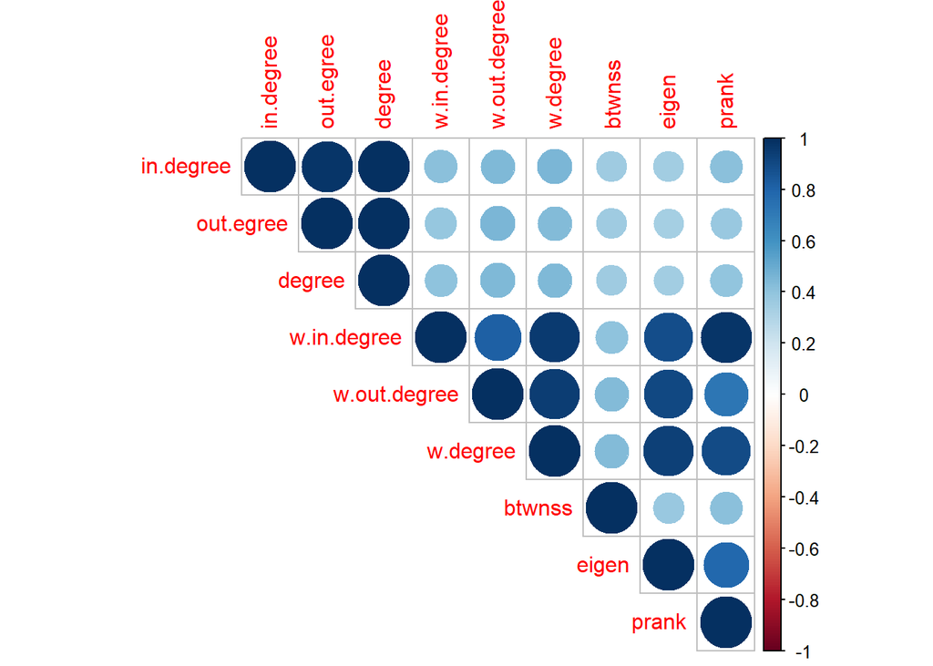

```r
cor.mat <- cor(centralities[,c(2:10)])
corrplot(cor.mat, type="upper")
```

The correlation matrix shows that betweenness centrality is often less correlated with degree or eigenvector centrality. This makes sense because betweenness focuses on a node’s role as a bridge, connecting other nodes in the network, rather than its direct connections or overall influence.

# Network visualisation

```r
q <- quantile(strength(net), .9)
low_nodes <- V(net)[strength(net) < q]
net.central <- delete.vertices(net, low_nodes)
V(net.central)
```

```
## + 27/27 vertices, named, from ec5274f:
##  [1] 37  48  61  68  79  107 112 132 138 142 148 161 162 163 164 170 186 230 231
## [20] 234 236 237 239 246 249 255 265
```

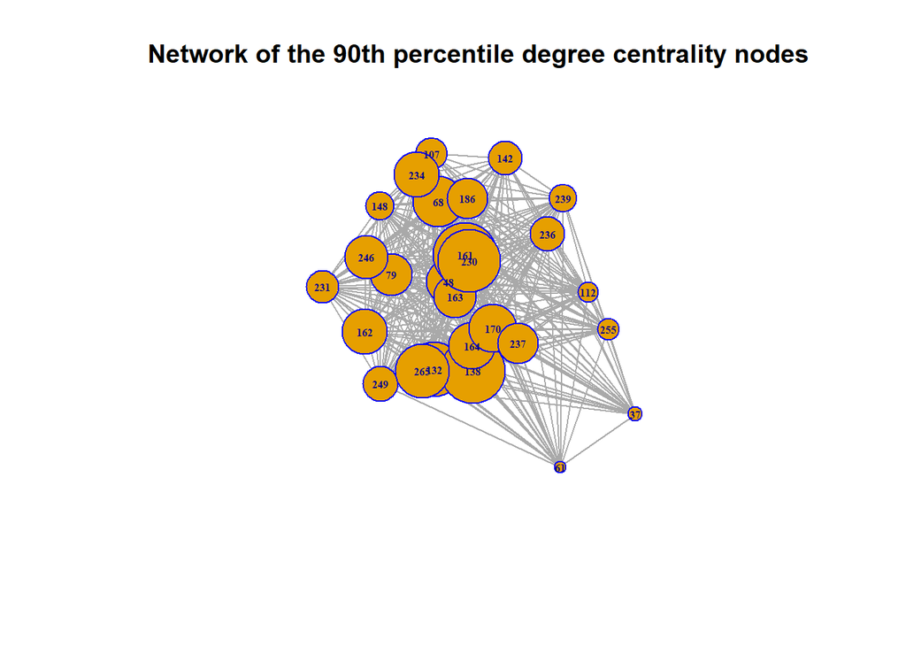

```r
plot(net.central,
     layout = layout.fruchterman.reingold,
     main='Network of the 90th percentile degree centrality nodes',
     vertex.frame.color='blue',
     vertex.label=V(net.central)$id,
     vertex.label.font=2,
     vertex.label.cex=.5,
     edge.arrow.size=0,
     vertex.size=strength(net.central)*0.0001)
```

The resulting graph includes the top 10% of nodes based on weighted degree centrality, representing the zones with the highest traffic intensity. The node sizes are scaled to reflect their importance, emphasizing zones with the most significant traffic volume.

# Community detection

```r
net.und <- as.undirected(net,
                         mode=c("mutual"),
                         edge.attr.comb = igraph_opt("edge.attr.comb"))
communities.net <- cluster_fast_greedy(net.und) %>%
print()
```

```
## IGRAPH clustering fast greedy, groups: 9, mod: 0.44
## + groups:
##   $`1`
##    [1] "2"   "7"   "8"   "9"   "10"  "15"  "16"  "19"  "27"  "28"  "30"  "38"
##   [13] "53"  "56"  "57"  "64"  "70"  "73"  "82"  "83"  "86"  "92"  "93"  "95"
##   [25] "96"  "98"  "101" "102" "117" "121" "122" "124" "129" "130" "131" "132"
##   [37] "134" "135" "139" "145" "146" "157" "160" "171" "173" "175" "179" "180"
##   [49] "191" "192" "193" "196" "197" "201" "202" "203" "205" "207" "215" "216"
##   [61] "218" "219" "223" "226" "252" "253" "258" "260" "265"
##
##   $`2`
##    [1] "5"   "6"   "23"  "44"  "84"  "99"  "109" "110" "115" "118" "156" "172"
##   + ... omitted several groups/vertices
```

```r
sizes(communities.net)
```

```
## Community sizes
##  1  2  3  4  5  6  7  8  9
## 69 20 62 57 53  1  1  1  1
```

To analyse the community structure, the directed graph is converted into an undirected graph, keeping only mutual edges where connections exist in both directions (A → B and B → A). This ensures that the undirected graph represents zones with reciprocal trip flows. Using the Fast Greedy Algorithm, nodes are grouped into communities by maximizing modularity, which measures how effectively the network is divided into clusters. The analysis identifies 9 communities with a modularity score of 0.44, indicating a moderate level of community structure. The community sizes reveal two distinct patterns. Five larger communities represent dense clusters of zones that are highly interconnected through mutual trips. These likely correspond to core areas where transportation demand is concentrated. In contrast, four single-node communities represent isolated zones with minimal connections to others, suggesting they do not integrate well into the larger network structure.

```r
# check the data structures
str(communities.net)
```

```
## Class 'communities'  hidden list of 6
##  $ merges    : num [1:260, 1:2] 265 237 161 141 162 140 263 229 273 163 ...
##  $ modularity: num [1:261] -0.00765 -0.004662 -0.002918 -0.000949 0.000921 ...
##  $ membership: num [1:265] 5 1 4 5 2 2 1 1 1 1 ...
##  $ names     : chr [1:265] "1" "2" "3" "4" ...
##  $ algorithm : chr "fast greedy"
##  $ vcount    : num 265
```

```r
str(zone_id)
```

```
## 'data.frame':    265 obs. of  2 variables:
##  $ LocationID: int  1 2 3 4 5 6 7 8 9 10 ...
##  $ Zone      : chr  "Newark Airport" "Jamaica Bay" "Allerton/Pelham Gardens" "Alphabet City" ...
```

```r
# change the data type to ensure joining
zone_id <- zone_id %>%
  mutate(LocationID = as.character(LocationID))
```

```r
communities.net_membership <- membership(communities.net) %>%
  unclass() %>%
  as.data.frame() %>%
  rename(community = ".") %>%
  rownames_to_column("LocationID") %>%
  left_join(zone_id, by = "LocationID") %>%
  arrange(community) %>%
  glimpse()
```

```
## Rows: 265
## Columns: 3
## $ LocationID <chr> "2", "7", "8", "9", "10", "15", "16", "19", "27", "28", "30…
## $ community  <dbl> 1, 1, 1, 1, 1, 1, 1, 1, 1, 1, 1, 1, 1, 1, 1, 1, 1, 1, 1, 1,…
## $ Zone       <chr> "Jamaica Bay", "Astoria", "Astoria Park", "Auburndale", "Ba…
```

```r
taxi_zones <- st_read("data/taxi_zones.shp") %>%
  glimpse()
```

```
## Rows: 263
## Columns: 7
## $ OBJECTID   <int> 1, 2, 3, 4, 5, 6, 7, 8, 9, 10, 11, 12, 13, 14, 15, 16, 17, …
## $ Shape_Leng <dbl> 0.11635745, 0.43346967, 0.08434111, 0.04356653, 0.09214649,…
## $ Shape_Area <dbl> 7.823068e-04, 4.866340e-03, 3.144142e-04, 1.118719e-04, 4.9…
## $ zone       <chr> "Newark Airport", "Jamaica Bay", "Allerton/Pelham Gardens",…
## $ LocationID <int> 1, 2, 3, 4, 5, 6, 7, 8, 9, 10, 11, 12, 13, 14, 15, 16, 17, …
## $ borough    <chr> "EWR", "Queens", "Bronx", "Manhattan", "Staten Island", "St…
## $ geometry   <MULTIPOLYGON [US_survey_foot]> MULTIPOLYGON (((933100.9 19..., M…
```

```r
# create two new rows
empty_data <- data.frame(matrix(NA, nrow = 2, ncol = ncol(taxi_zones) - 1))
colnames(empty_data) <- colnames(taxi_zones)[-ncol(taxi_zones)]
empty_geometries <- st_sfc(st_geometrycollection(), st_geometrycollection(), crs = st_crs(taxi_zones))

empty_rows <- st_sf(empty_data, geometry = empty_geometries)
taxi_zones <- rbind(taxi_zones, empty_rows)

taxi_zones <- taxi_zones[, !(colnames(taxi_zones) %in% "LocationID")]
colnames(taxi_zones)[colnames(taxi_zones) == "OBJECTID"] <- "LocationID"

taxi_zones$LocationID[264] <- 264
taxi_zones$LocationID[265] <- 265
taxi_zones$zone[265] <- "Outside of NYC"
glimpse(taxi_zones)
```

```
## Rows: 265
## Columns: 6
## $ LocationID <dbl> 1, 2, 3, 4, 5, 6, 7, 8, 9, 10, 11, 12, 13, 14, 15, 16, 17, …
## $ Shape_Leng <dbl> 0.11635745, 0.43346967, 0.08434111, 0.04356653, 0.09214649,…
## $ Shape_Area <dbl> 7.823068e-04, 4.866340e-03, 3.144142e-04, 1.118719e-04, 4.9…
## $ zone       <chr> "Newark Airport", "Jamaica Bay", "Allerton/Pelham Gardens",…
## $ borough    <chr> "EWR", "Queens", "Bronx", "Manhattan", "Staten Island", "St…
## $ geometry   <MULTIPOLYGON [US_survey_foot]> MULTIPOLYGON (((933100.9 19..., M…
```

```r
taxi_zones_full <- merge(taxi_zones, communities.net_membership, by = "LocationID")
sapply(taxi_zones_full, function(x) sum(is.na(x)))
```

```
## LocationID Shape_Leng Shape_Area       zone    borough  community       Zone
##          0          2          2          1          2          0          0
##   geometry
##          0
```

After retrieving the community membership for each node, we can identify which zones belong to each community. Before mapping, the Taxi Zones Shapefile is read, as it provides the geometric boundaries of the zones. However, the shapefile is missing the last two rows from the Taxi Zone Lookup Table. To address this, two rows with empty geometry are manually added (both likely representing “Outside of NYC”), ensuring that the taxi zones and community memberships can be properly merged. Following the merge, a few NA values remain, but they do not prevent the graphing process. The merged dataset is now ready for visualisation.

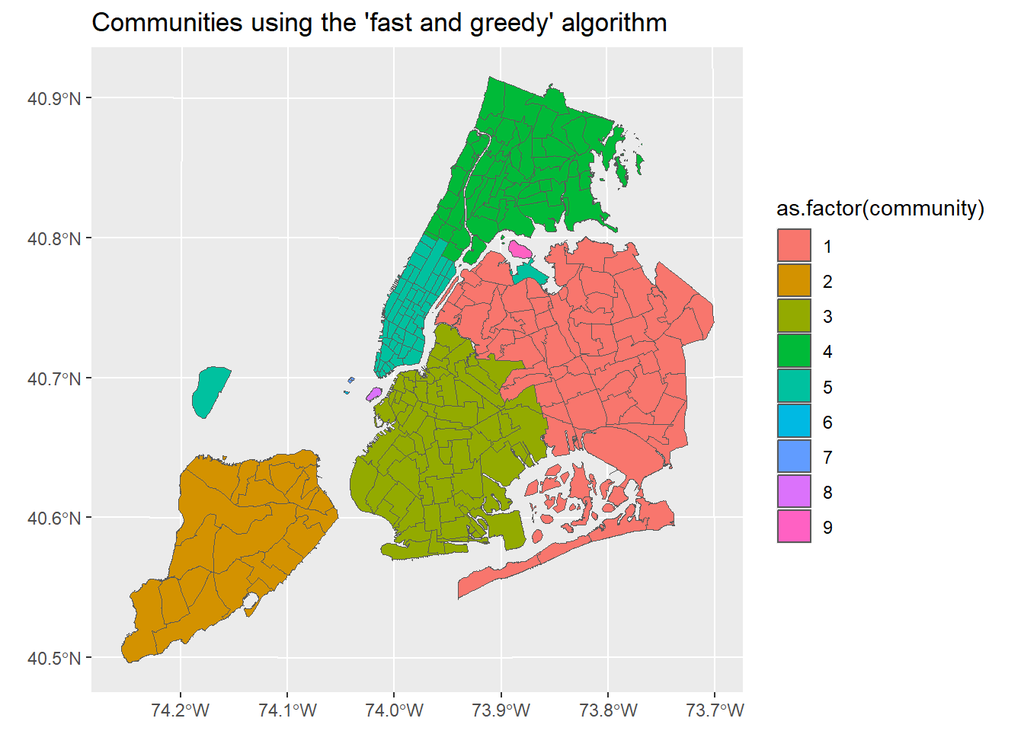

```r
ggplot(taxi_zones_full, aes(fill = as.factor(community))) +
  geom_sf() +
  ggtitle("Communities using the 'fast and greedy' algorithm")
```

# Mapping

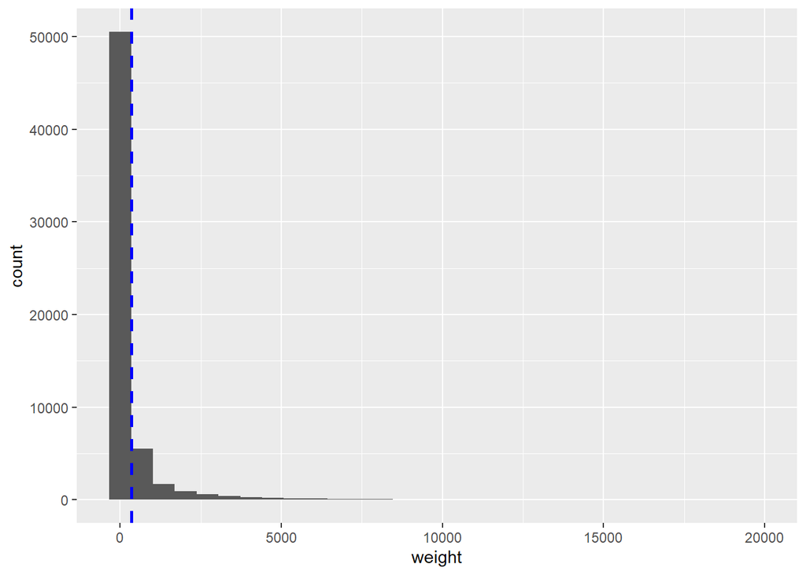

```r
options(scipen=999)
ggplot(all[all$weight < 20000,],
       aes(x=weight)) +
  geom_histogram() +
  geom_vline(aes(xintercept=mean(weight)),
             color="blue",
             linetype="dashed",
             size=1)
```

```r
all_truncated <- all %>%
  filter(weight > 5) %>%
  glimpse()
```

```
## Rows: 49,877
## Columns: 3
## $ from   <int> 1, 1, 1, 1, 1, 1, 1, 1, 1, 1, 1, 1, 1, 1, 1, 1, 1, 1, 1, 1, 1, …
## $ to     <int> 13, 25, 33, 42, 48, 49, 50, 68, 79, 87, 90, 100, 107, 113, 114,…
## $ weight <int> 10, 7, 9, 6, 71, 10, 29, 31, 27, 30, 13, 9, 10, 15, 12, 13, 6, …
```

```r
all_filtered <- all_truncated %>%
  filter(!(from %in% c(264, 265) | to %in% c(264, 265)))

taxi_zones_fixed <- taxi_zones_full[-((nrow(taxi_zones_full) - 1):nrow(taxi_zones_full)), ]

taxi_network <- od2line(flow = all_filtered, zones = taxi_zones_fixed)
```

```
## Creating centroids representing desire line start and end points.
```

```r
st_crs(taxi_network)
```

```
## Coordinate Reference System:
##   User input: NAD83 / New York Long Island (ftUS)
##   wkt:
## PROJCRS["NAD83 / New York Long Island (ftUS)",
##     BASEGEOGCRS["NAD83",
##         DATUM["North American Datum 1983",
##             ELLIPSOID["GRS 1980",6378137,298.257222101,
##                 LENGTHUNIT["metre",1]]],
##         PRIMEM["Greenwich",0,
##             ANGLEUNIT["degree",0.0174532925199433]],
##         ID["EPSG",4269]],
##     CONVERSION["SPCS83 New York Long Island zone (US survey foot)",
##         METHOD["Lambert Conic Conformal (2SP)",
##             ID["EPSG",9802]],
##         PARAMETER["Latitude of false origin",40.1666666666667,
##             ANGLEUNIT["degree",0.0174532925199433],
##             ID["EPSG",8821]],
##         PARAMETER["Longitude of false origin",-74,
##             ANGLEUNIT["degree",0.0174532925199433],
##             ID["EPSG",8822]],
##         PARAMETER["Latitude of 1st standard parallel",41.0333333333333,
##             ANGLEUNIT["degree",0.0174532925199433],
##             ID["EPSG",8823]],
##         PARAMETER["Latitude of 2nd standard parallel",40.6666666666667,
##             ANGLEUNIT["degree",0.0174532925199433],
##             ID["EPSG",8824]],
##         PARAMETER["Easting at false origin",984250,
##             LENGTHUNIT["US survey foot",0.304800609601219],
##             ID["EPSG",8826]],
##         PARAMETER["Northing at false origin",0,
##             LENGTHUNIT["US survey foot",0.304800609601219],
##             ID["EPSG",8827]]],
##     CS[Cartesian,2],
##         AXIS["easting (X)",east,
##             ORDER[1],
##             LENGTHUNIT["US survey foot",0.304800609601219]],
##         AXIS["northing (Y)",north,
##             ORDER[2],
##             LENGTHUNIT["US survey foot",0.304800609601219]],
##     USAGE[
##         SCOPE["Engineering survey, topographic mapping."],
##         AREA["United States (USA) - New York - counties of Bronx; Kings; Nassau; New York; Queens; Richmond; Suffolk."],
##         BBOX[40.47,-74.26,41.3,-71.8]],
##     ID["EPSG",2263]]
```

```r
taxi_network <- st_transform(taxi_network, crs = 4326)
```

```r
print(do.call(rbind, list(
  zone_id[grep("Newark Airport", zone_id$Zone), ],
  zone_id[grep("JFK Airport", zone_id$Zone), ],
  zone_id[grep("LaGuardia Airport", zone_id$Zone), ]
)))
```

```
##     LocationID              Zone
## 1            1    Newark Airport
## 132        132       JFK Airport
## 138        138 LaGuardia Airport
```

```r
Flow_pal <- colorQuantile("YlOrBr", domain = taxi_network$weight, n = 5)

taxi_network$zone.groups = "Rest"
taxi_network$zone.groups[taxi_network$from == "1" | taxi_network$to == "1"] = "Newark Airport"
taxi_network$zone.groups[taxi_network$from == "132" | taxi_network$to == "132"] = "JFK Airport"
taxi_network$zone.groups[taxi_network$from == "138" | taxi_network$to == "138"] = "LaGuardia Airport"

leaflet() %>%
  addTiles() %>%
  addPolylines(
    data = taxi_network,
    weight = 1,
    color = ~Flow_pal(weight),
    opacity = .8,
    group = taxi_network$zone.groups) %>%
  addLayersControl(
    position = "bottomleft",
    overlayGroups = unique(taxi_network$zone.groups),
    options = layersControlOptions(
      collapsed = FALSE)) %>%
  addLegend("topright",
          pal = Flow_pal,
          values = taxi_network$weight,
          title = "NYC Taxi Flows")
```

[interactive chart not shown]

This interactive map visualises taxi flows in NYC as lines connecting different zones. The lines are color-coded to represent flow intensity (weight), with higher-volume trips appearing more distinctly. Additionally, specific layers for Newark Airport, JFK Airport, and LaGuardia Airport enable users to see trips associated with these major transportation hubs.

# Network models

```r
nodes <- vcount(net)
edges <- ecount(net)

edges_possible <- nodes * (nodes - 1)
p <- edges / edges_possible
p
```

```
## [1] 0.8710692
```

```r
set.seed(55)
gnp <- sample_gnp(n = nodes, p = p)
pa <- sample_pa(n = nodes, directed=TRUE)
sw <- sample_smallworld(dim = 1, size = nodes, nei = 5, p = 0.05)
```

To analyse the network further, we use the nodes and edges from the real network along with the calculated edge probability to generate three different random graph models. Setting a random seed ensures reproducibility and consistency in the simulations. By controlling the randomness in these stochastic processes, we can replicate results, make fair comparisons between the models and the real network, and debug simulations effectively.

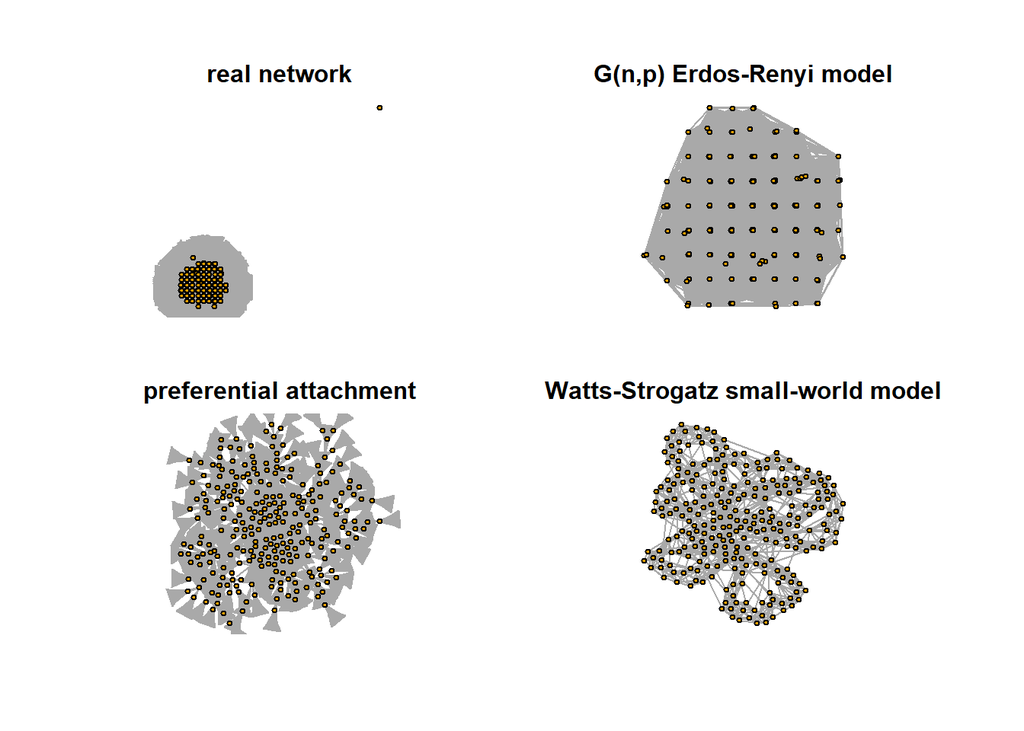

```r
par(mfrow = c(2, 2), mar = c(2, 2, 2, 2), oma = c(2, 2, 2, 2))

plot(net,
     layout = layout_with_graphopt,
     vertex.label=NA,
     vertex.size = 5,
     main='real network')

plot(gnp,
     layout=layout_with_graphopt,
     vertex.label=NA,
     vertex.size = 5,
     main='G(n,p) Erdos-Renyi model')

plot(pa,
     layout=layout_with_graphopt,
     vertex.label=NA,
     vertex.size = 5,
     main='preferential attachment')

plot(sw,
     layout=layout_with_graphopt,
     vertex.label=NA,
     vertex.size = 5,
     main='Watts-Strogatz small-world model')
```

The Erdős-Rényi Model generates a network with edges distributed uniformly and no visible clusters or hubs, as edges are randomly placed with a fixed probability. This results in a structure that lacks the uneven connectivity patterns seen in real-world networks. The Preferential Attachment Model produces a scale-free network characterized by prominent hubs, where some nodes have significantly more connections than others. This occurs because new nodes are more likely to connect to high-degree nodes, following the “rich-get-richer” principle. This model aligns with real-world networks if key hubs dominate trip flows. The Watts-Strogatz Small-World Model combines strong local clustering with a few long-range connections that shorten path lengths. This balance of regularity and randomness reflects networks with localized zones of high activity (e.g., within Manhattan) and key shortcuts (e.g., inter-borough connections), resembling the connectivity observed in urban taxi networks.

```r
d.gnp <- diameter(gnp, directed = TRUE, weights = NA)
d.pa <- diameter(pa, directed = TRUE, weights = NA)
d.sw <- diameter(sw, directed = TRUE, weights = NA)

mean_ditst.gnp <- mean_distance(gnp)
mean_ditst.pa <- mean_distance(pa)
mean_ditst.sw <- mean_distance(sw)

dens.gnp <- edge_density(gnp)
dens.pa <- edge_density(pa)
dens.sw <- edge_density(sw)

trans.gnp <- transitivity(gnp)
trans.pa <- transitivity(pa)
trans.sw <- transitivity(sw)

rec.gnp <- reciprocity(gnp)
rec.pa <- reciprocity(pa)
rec.sw <- reciprocity(sw)

ass.gnp <- assortativity_degree(gnp, directed = T)
ass.pa <- assortativity_degree(pa, directed = T)
ass.sw <- assortativity_degree(sw, directed = T)

compare_network_measures <- data.frame(
  Metric = c("Diameter", "Mean Distance", "Density", "Transitivity", "Reciprocity", "Assortativity"),
  real = c(d, mean_ditst, dens, trans, rec, ass),
  gnp = c(d.gnp, mean_ditst.gnp, dens.gnp, trans.gnp, rec.gnp, ass.gnp),
  pa = c(d.pa, mean_ditst.pa, dens.pa, trans.pa, rec.pa, ass.pa),
  sw = c(d.sw, mean_ditst.sw, dens.sw, trans.sw, rec.sw, ass.sw)
) %>%
print()
```

```
##          Metric        real          gnp          pa           sw
## 1      Diameter  3.00000000  2.000000000 6.000000000  7.000000000
## 2 Mean Distance  2.43836531  1.130245855 2.170860927  3.596769583
## 3       Density  0.87106918  0.869754145 0.003773585  0.037878788
## 4  Transitivity  0.95467329  0.869595945 0.000000000  0.522324769
## 5   Reciprocity  0.96567115  1.000000000 0.000000000  1.000000000
## 6 Assortativity -0.06126687 -0.005645916         NaN -0.009508368
```

# Spatial interaction modelling

```r
zone.d <- CreateDistMatrix(taxi_zones_fixed, taxi_zones_fixed, longlat = T)

rownames(zone.d) <- taxi_zones_fixed$LocationID
colnames(zone.d) <- taxi_zones_fixed$LocationID

zone.d <- as.data.frame.table(zone.d, responseName = "value") %>%
  filter(Var1 != Var2) %>%
  glimpse()
```

```
## Rows: 68,906
## Columns: 3
## $ Var1  <fct> 2, 3, 4, 5, 6, 7, 8, 9, 10, 11, 12, 13, 14, 15, 16, 17, 18, 19, …
## $ Var2  <fct> 1, 1, 1, 1, 1, 1, 1, 1, 1, 1, 1, 1, 1, 1, 1, 1, 1, 1, 1, 1, 1, 1…
## $ value <dbl> 30263.94, 33536.56, 16983.20, 15523.38, 13338.81, 22786.73, 2323…
```

```r
zone.d <- zone.d %>%
  mutate(Var1 = as.character(Var1),
         Var2 = as.character(Var2))

all <- all %>%
  mutate(from = as.character(from),
         to = as.character(to))
```

```r
all_distance <- all %>%
  inner_join(zone.d, by = c("from" = "Var1", "to" = "Var2")) %>%
  rename(distance = value) %>%
  glimpse()
```

```
## Rows: 60,080
## Columns: 4
## $ from     <chr> "1", "1", "1", "1", "1", "1", "1", "1", "1", "1", "1", "1", "…
## $ to       <chr> "4", "5", "6", "13", "14", "23", "24", "25", "26", "29", "33"…
## $ weight   <int> 3, 1, 1, 10, 1, 3, 2, 7, 1, 1, 9, 1, 1, 3, 3, 2, 6, 2, 4, 71,…
## $ distance <dbl> 16983.20, 15523.38, 13338.81, 13500.89, 14257.23, 9497.69, 21…
```

```r
origin_totals <- all %>%
  group_by(from) %>%
  summarise(origin_trips = sum(weight), .groups = "drop")

destination_totals <- all %>%
  group_by(to) %>%
  summarise(dest_trips = sum(weight), .groups = "drop")
```

```r
interaction <- all_distance %>%
  left_join(origin_totals, by = "from") %>%
  left_join(destination_totals, by = "to") %>%
  as.data.frame(interaction) %>%
  glimpse()
```

```
## Rows: 60,080
## Columns: 6
## $ from         <chr> "1", "1", "1", "1", "1", "1", "1", "1", "1", "1", "1", "1…
## $ to           <chr> "4", "5", "6", "13", "14", "23", "24", "25", "26", "29", …
## $ weight       <int> 3, 1, 1, 10, 1, 3, 2, 7, 1, 1, 9, 1, 1, 3, 3, 2, 6, 2, 4,…
## $ distance     <dbl> 16983.20, 15523.38, 13338.81, 13500.89, 14257.23, 9497.69…
## $ origin_trips <int> 1225, 1225, 1225, 1225, 1225, 1225, 1225, 1225, 1225, 122…
## $ dest_trips   <int> 60223, 5415, 12251, 106118, 82498, 29076, 32663, 101427, …
```

To analyse trip flows between taxi zones, a distance matrix was created for all zone pairs. Since population data of NYC by taxi zones is unavailable, the total trips to and from each location were used as proxies. Log-Linear Regression and Poisson Regression were applied and compared.

```r
ols.model <- lm(
  log(weight+.5) ~ log(origin_trips) + log(dest_trips) + log(distance),
  data = interaction)

summary(ols.model)
```

```
##
## Call:
## lm(formula = log(weight + 0.5) ~ log(origin_trips) + log(dest_trips) +
##     log(distance), data = interaction)
##
## Residuals:
##     Min      1Q  Median      3Q     Max
## -6.0992 -0.5620 -0.0363  0.5253  4.7583
##
## Coefficients:
##                    Estimate Std. Error t value            Pr(>|t|)
## (Intercept)        6.816197   0.082441   82.68 <0.0000000000000002 ***
## log(origin_trips)  0.695491   0.003291  211.35 <0.0000000000000002 ***
## log(dest_trips)    0.668870   0.003459  193.39 <0.0000000000000002 ***
## log(distance)     -1.913473   0.005497 -348.07 <0.0000000000000002 ***
## ---
## Signif. codes:  0 '***' 0.001 '**' 0.01 '*' 0.05 '.' 0.1 ' ' 1
##
## Residual standard error: 0.8975 on 60076 degrees of freedom
## Multiple R-squared:  0.8032, Adjusted R-squared:  0.8032
## F-statistic: 8.172e+04 on 3 and 60076 DF,  p-value: < 0.00000000000000022
```

```r
glm.model <- glm(
  weight ~ log(origin_trips) + log(dest_trips) + log(distance),
  data = interaction,
  family = poisson(link = "log")
)
summary(glm.model)
```

```
##
## Call:
## glm(formula = weight ~ log(origin_trips) + log(dest_trips) +
##     log(distance), family = poisson(link = "log"), data = interaction)
##
## Coefficients:
##                     Estimate Std. Error z value            Pr(>|z|)
## (Intercept)        2.4918796  0.0056902   437.9 <0.0000000000000002 ***
## log(origin_trips)  0.6168784  0.0002967  2079.1 <0.0000000000000002 ***
## log(dest_trips)    0.6198521  0.0003038  2040.2 <0.0000000000000002 ***
## log(distance)     -1.1991978  0.0002377 -5045.1 <0.0000000000000002 ***
## ---
## Signif. codes:  0 '***' 0.001 '**' 0.01 '*' 0.05 '.' 0.1 ' ' 1
##
## (Dispersion parameter for poisson family taken to be 1)
##
##     Null deviance: 67939899  on 60079  degrees of freedom
## Residual deviance: 16506886  on 60076  degrees of freedom
## AIC: 16841156
##
## Number of Fisher Scoring iterations: 5
```

```r
stargazer(ols.model, glm.model, type = "text")
```

```
##
## ================================================================
##                                 Dependent variable:
##                     --------------------------------------------
##                           log(weight + 0.5)           weight
##                                  OLS                 Poisson
##                                  (1)                   (2)
## ----------------------------------------------------------------
## log(origin_trips)             0.695***               0.617***
##                                (0.003)               (0.0003)
##
## log(dest_trips)               0.669***               0.620***
##                                (0.003)               (0.0003)
##
## log(distance)                 -1.913***             -1.199***
##                                (0.005)               (0.0002)
##
## Constant                      6.816***               2.492***
##                                (0.082)               (0.006)
##
## ----------------------------------------------------------------
## Observations                   60,080                 60,080
## R2                              0.803
## Adjusted R2                     0.803
## Log Likelihood                                    -8,420,574.000
## Akaike Inf. Crit.                                 16,841,156.000
## Residual Std. Error      0.898 (df = 60076)
## F Statistic         81,717.320*** (df = 3; 60076)
## ================================================================
## Note:                                *p<0.1; **p<0.05; ***p<0.01
```

The coefficients across both models were consistent, with slightly smaller values observed in the Poisson model. All predictors (origin zone total trips, destination zone total trips, and distance between zones) were highly significant (p < 0.001) in both models, indicating a strong relationship with trip weights. For model fit, the Log-Linear Regression (OLS) showed that 80.3% of the variation in log-transformed trip weights was explained by the predictors. The residual standard error of 0.898 suggests minimal unexplained variation, while the F-statistic confirmed the overall significance of the model. In the Poisson Regression, the residual deviance was substantially lower than the null deviance, demonstrating a good model fit and the effectiveness of the predictors in explaining variation in trip weights.

```r
set.seed(123)

train.index <- createDataPartition(interaction$weight,
                                   p = 0.8, list = FALSE, times = 1)

train <- interaction[train.index, ]
test <- interaction[-train.index, ]

model.lm <- train(
  weight ~ origin_trips + dest_trips + distance,
  data = train,
  method = "lm")

predictions.lm <- predict(model.lm, newdata = test)
lm.metrics <- postResample(pred = predictions.lm, obs = test$weight)

model.glm <- train(
  weight ~ origin_trips + dest_trips + distance,
  data = train,
  method = "glmnet",
  family = "poisson",
  na.action = na.omit)

predictions.glm <- predict(model.glm, test)
glm.metrics <- postResample(pred = predictions.glm, obs = test$weight)

bind_rows(lm.metrics, glm.metrics) %>%
  mutate(Model = c("lm", "glm")) %>%
  select(Model, Rsquared, RMSE, MAE) %>%
  kable(digits = 3)
```

| Model | Rsquared | RMSE | MAE |
| --- | --- | --- | --- |
| lm | 0.249 | 969.201 | 462.313 |
| glm | 0.554 | 767.960 | 259.128 |

Comparing the two models, the GLM model demonstrates better performance. It has a higher R-squared value, indicating that it explains more variance in the data. Additionally, the GLM model exhibits a smaller RMSE, signifying lower prediction errors, and a smaller MAE, reflecting smaller absolute errors. Overall, the GLM model outperforms the LM model in capturing the relationships and predicting trip weights more accurately.

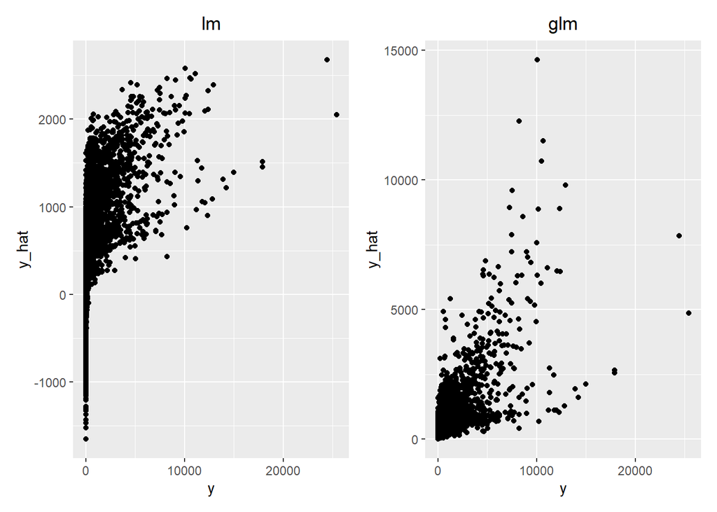

```r
predict.lm.plot <- bind_cols(test$weight, predictions.lm) %>%
  rename(y = '...1',
         y_hat = '...2') %>%
  ggplot(aes(x=y, y=y_hat)) + geom_point() + ggtitle("lm") +
  theme(plot.title = element_text(hjust = 0.5))
predict.glm.plot <- bind_cols(test$weight, predictions.glm) %>%
  rename(y = '...1',
         y_hat = '...2') %>%
  ggplot(aes(x=y, y=y_hat)) + geom_point() + ggtitle("glm") +
  theme(plot.title = element_text(hjust = 0.5))
predict.lm.plot + predict.glm.plot
```

From the two plots, it is evident that the LM model’s predicted values cluster heavily in the lower range, with a few extreme predictions for higher actual values. This suggests the model struggles with larger weights, resulting in overdispersion in its predictions. In contrast, the GLM model’s predicted values align more closely with the actual values, particularly in the lower range. However, similar to the LM model, the GLM model underpredicts some of the very high actual values, indicating room for improvement in capturing extreme weights.

# Accessibility

```r
accessibility <- interaction %>%
  mutate(accessibility = weight / distance) %>%
  group_by(from) %>%
  summarise(accessibility_score = sum(accessibility, na.rm = TRUE), .groups = "drop") %>%
  arrange(desc(accessibility_score)) %>%
  glimpse()
```

```
## Rows: 261
## Columns: 2
## $ from                <chr> "161", "230", "164", "234", "68", "162", "170", "2…
## $ accessibility_score <dbl> 192.78777, 160.85880, 134.39205, 132.52895, 130.69…
```

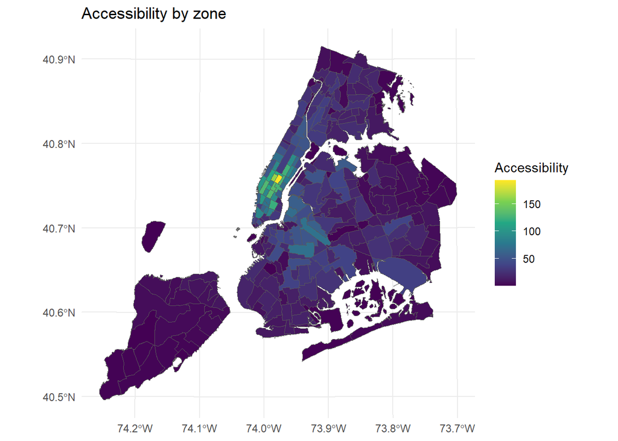

```r
taxi_zones_fixed <- taxi_zones_fixed %>%
  mutate(LocationID = as.character(LocationID))

spatial_accessibility <- taxi_zones_fixed %>%
  left_join(accessibility, by = c("LocationID" = "from"))

ggplot(spatial_accessibility) +
  geom_sf(aes(fill = accessibility_score)) +
  scale_fill_viridis_c() +
  labs(title = "Accessibility by zone",
       fill = "Accessibility") +
  theme_minimal()
```

The accessibility map highlights that Central Manhattan, particularly Midtown, has the highest accessibility. This area serves as a hub for business, tourism, and entertainment. The high accessibility scores are driven by the geographic proximity of zones within Manhattan, resulting in shorter average travel distances, and by strong connections to major transit hubs like Penn Station and Grand Central Terminal. Zones in the outer boroughs near Manhattan, such as parts of western Brooklyn and western Queens, show moderate accessibility. These areas benefit from their adjacency to Manhattan, often serving as residential zones for commuters and acting as connectors between Manhattan and other outer boroughs. Staten Island, on the other hand, exhibits very low accessibility. Its geographic isolation and limited connections to other boroughs (primarily through bridges or ferries) contribute to its lower accessibility scores.

# References

Schneider, T. W. (2015). Analyzing 1.1 Billion NYC Taxi and Uber Trips, with a Vengeance. Retrieved from https://toddwschneider.com/posts/analyzing-1-1-billion-nyc-taxi-and-uber-trips-with-a-vengeance/

Deri, J., & Moura, J. M. F. (2015). Taxi Data in New York City: A Network Perspective. IEEE Xplore. Retrieved from https://ieeexplore.ieee.org/document/7421468

Gilbride, M., et al. (2017). Zooming in on NYC Taxi Data with Portal. arXiv. Retrieved from https://arxiv.org/pdf/1709.06176